# Risk Factor Analysis

## Outcome Variable

**Outcome Variable:** stunted

## Predictor Variables

**Intervention Variable:** enstunt

**Adjustment Set:**

unadjusted

## Stratifying Variables

The analysis was stratified on these variable(s):

- agecat
- studyid
- country

## Data Summary

| agecat | studyid | country | enstunt | stunted | n_cell | n | outcome_variable |
| --- | --- | --- | --- | --- | --- | --- | --- |
| Birth | ki0047075b-MAL-ED | BANGLADESH | 0 | 0 | 187 | 231 | stunted |
| Birth | ki0047075b-MAL-ED | BANGLADESH | 0 | 1 | 0 | 231 | stunted |
| Birth | ki0047075b-MAL-ED | BANGLADESH | 1 | 0 | 0 | 231 | stunted |
| Birth | ki0047075b-MAL-ED | BANGLADESH | 1 | 1 | 44 | 231 | stunted |
| Birth | ki0047075b-MAL-ED | BRAZIL | 0 | 0 | 56 | 65 | stunted |
| Birth | ki0047075b-MAL-ED | BRAZIL | 0 | 1 | 0 | 65 | stunted |
| Birth | ki0047075b-MAL-ED | BRAZIL | 1 | 0 | 0 | 65 | stunted |
| Birth | ki0047075b-MAL-ED | BRAZIL | 1 | 1 | 9 | 65 | stunted |
| Birth | ki0047075b-MAL-ED | INDIA | 0 | 0 | 37 | 47 | stunted |
| Birth | ki0047075b-MAL-ED | INDIA | 0 | 1 | 0 | 47 | stunted |
| Birth | ki0047075b-MAL-ED | INDIA | 1 | 0 | 0 | 47 | stunted |
| Birth | ki0047075b-MAL-ED | INDIA | 1 | 1 | 10 | 47 | stunted |
| Birth | ki0047075b-MAL-ED | NEPAL | 0 | 0 | 25 | 27 | stunted |
| Birth | ki0047075b-MAL-ED | NEPAL | 0 | 1 | 0 | 27 | stunted |
| Birth | ki0047075b-MAL-ED | NEPAL | 1 | 0 | 0 | 27 | stunted |
| Birth | ki0047075b-MAL-ED | NEPAL | 1 | 1 | 2 | 27 | stunted |
| Birth | ki0047075b-MAL-ED | PERU | 0 | 0 | 207 | 233 | stunted |
| Birth | ki0047075b-MAL-ED | PERU | 0 | 1 | 0 | 233 | stunted |
| Birth | ki0047075b-MAL-ED | PERU | 1 | 0 | 0 | 233 | stunted |
| Birth | ki0047075b-MAL-ED | PERU | 1 | 1 | 26 | 233 | stunted |
| Birth | ki0047075b-MAL-ED | SOUTH AFRICA | 0 | 0 | 113 | 123 | stunted |
| Birth | ki0047075b-MAL-ED | SOUTH AFRICA | 0 | 1 | 0 | 123 | stunted |
| Birth | ki0047075b-MAL-ED | SOUTH AFRICA | 1 | 0 | 0 | 123 | stunted |
| Birth | ki0047075b-MAL-ED | SOUTH AFRICA | 1 | 1 | 10 | 123 | stunted |
| Birth | ki0047075b-MAL-ED | TANZANIA, UNITED REPUBLIC OF | 0 | 0 | 102 | 125 | stunted |
| Birth | ki0047075b-MAL-ED | TANZANIA, UNITED REPUBLIC OF | 0 | 1 | 0 | 125 | stunted |
| Birth | ki0047075b-MAL-ED | TANZANIA, UNITED REPUBLIC OF | 1 | 0 | 0 | 125 | stunted |
| Birth | ki0047075b-MAL-ED | TANZANIA, UNITED REPUBLIC OF | 1 | 1 | 23 | 125 | stunted |
| Birth | ki1000108-CMC-V-BCS-2002 | INDIA | 0 | 0 | 75 | 92 | stunted |
| Birth | ki1000108-CMC-V-BCS-2002 | INDIA | 0 | 1 | 0 | 92 | stunted |

[output cut: 298 more lines]

The following strata were considered:

- agecat: 24 months, studyid: ki0047075b-MAL-ED, country: BANGLADESH
- agecat: 24 months, studyid: ki0047075b-MAL-ED, country: BRAZIL
- agecat: 24 months, studyid: ki0047075b-MAL-ED, country: INDIA
- agecat: 24 months, studyid: ki0047075b-MAL-ED, country: NEPAL
- agecat: 24 months, studyid: ki0047075b-MAL-ED, country: PERU
- agecat: 24 months, studyid: ki0047075b-MAL-ED, country: SOUTH AFRICA
- agecat: 24 months, studyid: ki0047075b-MAL-ED, country: TANZANIA, UNITED REPUBLIC OF
- agecat: 24 months, studyid: ki1000108-CMC-V-BCS-2002, country: INDIA
- agecat: 24 months, studyid: ki1000108-IRC, country: INDIA
- agecat: 24 months, studyid: ki1000109-EE, country: PAKISTAN
- agecat: 24 months, studyid: ki1017093-NIH-Birth, country: BANGLADESH
- agecat: 24 months, studyid: ki1017093b-PROVIDE, country: BANGLADESH
- agecat: 24 months, studyid: ki1017093c-NIH-Crypto, country: BANGLADESH
- agecat: 24 months, studyid: ki1066203-TanzaniaChild2, country: TANZANIA, UNITED REPUBLIC OF
- agecat: 24 months, studyid: ki1101329-Keneba, country: GAMBIA
- agecat: 24 months, studyid: ki1113344-GMS-Nepal, country: NEPAL
- agecat: 24 months, studyid: ki1114097-CMIN, country: BANGLADESH
- agecat: 24 months, studyid: ki1114097-CONTENT, country: PERU
- agecat: 24 months, studyid: ki1119695-PROBIT, country: BELARUS
- agecat: 24 months, studyid: ki1126311-ZVITAMBO, country: ZIMBABWE
- agecat: 24 months, studyid: ki1135781-COHORTS, country: GUATEMALA
- agecat: 24 months, studyid: ki1135781-COHORTS, country: INDIA
- agecat: 24 months, studyid: ki1135781-COHORTS, country: PHILIPPINES
- agecat: 24 months, studyid: ki1148112-LCNI-5, country: MALAWI
- agecat: 24 months, studyid: kiGH5241-JiVitA-3, country: BANGLADESH
- agecat: 24 months, studyid: kiGH5241-JiVitA-4, country: BANGLADESH
- agecat: 6 months, studyid: ki0047075b-MAL-ED, country: BANGLADESH
- agecat: 6 months, studyid: ki0047075b-MAL-ED, country: BRAZIL
- agecat: 6 months, studyid: ki0047075b-MAL-ED, country: INDIA
- agecat: 6 months, studyid: ki0047075b-MAL-ED, country: NEPAL
- agecat: 6 months, studyid: ki0047075b-MAL-ED, country: PERU
- agecat: 6 months, studyid: ki0047075b-MAL-ED, country: SOUTH AFRICA
- agecat: 6 months, studyid: ki0047075b-MAL-ED, country: TANZANIA, UNITED REPUBLIC OF
- agecat: 6 months, studyid: ki1000108-CMC-V-BCS-2002, country: INDIA
- agecat: 6 months, studyid: ki1000108-IRC, country: INDIA
- agecat: 6 months, studyid: ki1000109-EE, country: PAKISTAN
- agecat: 6 months, studyid: ki1000109-ResPak, country: PAKISTAN
- agecat: 6 months, studyid: ki1000304b-SAS-CompFeed, country: INDIA
- agecat: 6 months, studyid: ki1000304b-SAS-FoodSuppl, country: INDIA
- agecat: 6 months, studyid: ki1017093-NIH-Birth, country: BANGLADESH
- agecat: 6 months, studyid: ki1017093b-PROVIDE, country: BANGLADESH
- agecat: 6 months, studyid: ki1017093c-NIH-Crypto, country: BANGLADESH
- agecat: 6 months, studyid: ki1066203-TanzaniaChild2, country: TANZANIA, UNITED REPUBLIC OF
- agecat: 6 months, studyid: ki1101329-Keneba, country: GAMBIA
- agecat: 6 months, studyid: ki1112895-Guatemala BSC, country: GUATEMALA
- agecat: 6 months, studyid: ki1113344-GMS-Nepal, country: NEPAL
- agecat: 6 months, studyid: ki1114097-CMIN, country: BANGLADESH
- agecat: 6 months, studyid: ki1114097-CONTENT, country: PERU
- agecat: 6 months, studyid: ki1119695-PROBIT, country: BELARUS
- agecat: 6 months, studyid: ki1126311-ZVITAMBO, country: ZIMBABWE
- agecat: 6 months, studyid: ki1135781-COHORTS, country: GUATEMALA
- agecat: 6 months, studyid: ki1135781-COHORTS, country: INDIA
- agecat: 6 months, studyid: ki1135781-COHORTS, country: PHILIPPINES
- agecat: 6 months, studyid: ki1148112-LCNI-5, country: MALAWI
- agecat: 6 months, studyid: kiGH5241-JiVitA-3, country: BANGLADESH
- agecat: 6 months, studyid: kiGH5241-JiVitA-4, country: BANGLADESH
- agecat: Birth, studyid: ki0047075b-MAL-ED, country: BANGLADESH
- agecat: Birth, studyid: ki0047075b-MAL-ED, country: BRAZIL
- agecat: Birth, studyid: ki0047075b-MAL-ED, country: INDIA
- agecat: Birth, studyid: ki0047075b-MAL-ED, country: NEPAL
- agecat: Birth, studyid: ki0047075b-MAL-ED, country: PERU
- agecat: Birth, studyid: ki0047075b-MAL-ED, country: SOUTH AFRICA
- agecat: Birth, studyid: ki0047075b-MAL-ED, country: TANZANIA, UNITED REPUBLIC OF
- agecat: Birth, studyid: ki1000108-CMC-V-BCS-2002, country: INDIA
- agecat: Birth, studyid: ki1000108-IRC, country: INDIA
- agecat: Birth, studyid: ki1000109-EE, country: PAKISTAN
- agecat: Birth, studyid: ki1000109-ResPak, country: PAKISTAN
- agecat: Birth, studyid: ki1000304b-SAS-CompFeed, country: INDIA
- agecat: Birth, studyid: ki1017093-NIH-Birth, country: BANGLADESH
- agecat: Birth, studyid: ki1017093b-PROVIDE, country: BANGLADESH
- agecat: Birth, studyid: ki1017093c-NIH-Crypto, country: BANGLADESH
- agecat: Birth, studyid: ki1101329-Keneba, country: GAMBIA
- agecat: Birth, studyid: ki1113344-GMS-Nepal, country: NEPAL
- agecat: Birth, studyid: ki1114097-CMIN, country: BANGLADESH
- agecat: Birth, studyid: ki1114097-CONTENT, country: PERU
- agecat: Birth, studyid: ki1119695-PROBIT, country: BELARUS
- agecat: Birth, studyid: ki1126311-ZVITAMBO, country: ZIMBABWE
- agecat: Birth, studyid: ki1135781-COHORTS, country: GUATEMALA
- agecat: Birth, studyid: ki1135781-COHORTS, country: INDIA
- agecat: Birth, studyid: ki1135781-COHORTS, country: PHILIPPINES
- agecat: Birth, studyid: kiGH5241-JiVitA-3, country: BANGLADESH
- agecat: Birth, studyid: kiGH5241-JiVitA-4, country: BANGLADESH

### Dropped Strata

Some strata were dropped due to rare outcomes:

- agecat: Birth, studyid: ki0047075b-MAL-ED, country: BANGLADESH
- agecat: Birth, studyid: ki0047075b-MAL-ED, country: BRAZIL
- agecat: Birth, studyid: ki0047075b-MAL-ED, country: INDIA
- agecat: Birth, studyid: ki0047075b-MAL-ED, country: NEPAL
- agecat: Birth, studyid: ki0047075b-MAL-ED, country: PERU
- agecat: Birth, studyid: ki0047075b-MAL-ED, country: SOUTH AFRICA
- agecat: Birth, studyid: ki0047075b-MAL-ED, country: TANZANIA, UNITED REPUBLIC OF
- agecat: Birth, studyid: ki1000108-CMC-V-BCS-2002, country: INDIA
- agecat: Birth, studyid: ki1000108-IRC, country: INDIA
- agecat: Birth, studyid: ki1000109-EE, country: PAKISTAN
- agecat: Birth, studyid: ki1000109-ResPak, country: PAKISTAN
- agecat: Birth, studyid: ki1000304b-SAS-CompFeed, country: INDIA
- agecat: Birth, studyid: ki1017093-NIH-Birth, country: BANGLADESH
- agecat: Birth, studyid: ki1017093b-PROVIDE, country: BANGLADESH
- agecat: Birth, studyid: ki1017093c-NIH-Crypto, country: BANGLADESH
- agecat: Birth, studyid: ki1101329-Keneba, country: GAMBIA
- agecat: Birth, studyid: ki1113344-GMS-Nepal, country: NEPAL
- agecat: Birth, studyid: ki1114097-CMIN, country: BANGLADESH
- agecat: Birth, studyid: ki1114097-CONTENT, country: PERU
- agecat: Birth, studyid: ki1119695-PROBIT, country: BELARUS
- agecat: Birth, studyid: ki1126311-ZVITAMBO, country: ZIMBABWE
- agecat: Birth, studyid: ki1135781-COHORTS, country: GUATEMALA
- agecat: Birth, studyid: ki1135781-COHORTS, country: INDIA
- agecat: Birth, studyid: ki1135781-COHORTS, country: PHILIPPINES
- agecat: Birth, studyid: kiGH5241-JiVitA-3, country: BANGLADESH
- agecat: Birth, studyid: kiGH5241-JiVitA-4, country: BANGLADESH
- agecat: 6 months, studyid: ki0047075b-MAL-ED, country: BRAZIL
- agecat: 6 months, studyid: ki0047075b-MAL-ED, country: NEPAL
- agecat: 6 months, studyid: ki1148112-LCNI-5, country: MALAWI
- agecat: 24 months, studyid: ki0047075b-MAL-ED, country: BRAZIL
- agecat: 24 months, studyid: ki0047075b-MAL-ED, country: TANZANIA, UNITED REPUBLIC OF
- agecat: 24 months, studyid: ki1066203-TanzaniaChild2, country: TANZANIA, UNITED REPUBLIC OF
- agecat: 24 months, studyid: ki1119695-PROBIT, country: BELARUS

## Methods Detail

We’re interested in the causal parameters $E[Y_a]$ for all values of $a \in \mathcal{A}$. These parameters represent the mean outcome if, possibly contrary to fact, we intervened to set all units to have $A=a$. Under the randomization and positivity assumptions, these are identified by the statistical parameters $\psi_a=E_W[E_{Y|A,W}(Y|A=a,W)]$. In addition, we’re interested in the mean of $Y$, $E[Y]$ under no intervention (the observed mean). We will estimate these parameters by using SuperLearner to fit the relevant likelihood factors – $E_{Y|A,W}(Y|A=a,W)$ and $p(A=a|W)$, and then updating our likelihood fit using a joint TMLE.

For unadjusted analyses ($W=\{\}$), initial likelihoods were estimated using Lrnr_glm to estimate the simple $E(Y|A)$ and Lrnr_mean to estimate $p(A)$. For adjusted analyses, a small library containing Lrnr_glmnet, Lrnr_xgboost, and Lrnr_mean was used.

Having estimated these parameters, we will then use the delta method to estimate relative risks and attributable risks relative to a prespecified baseline level of $A$.

# Results Detail

## Results Plots

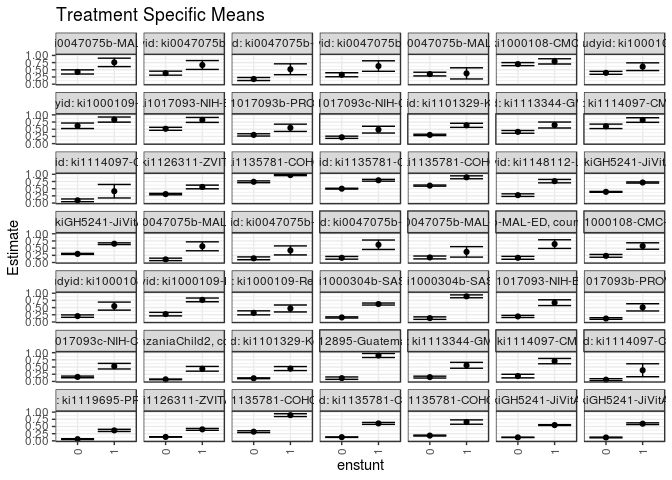

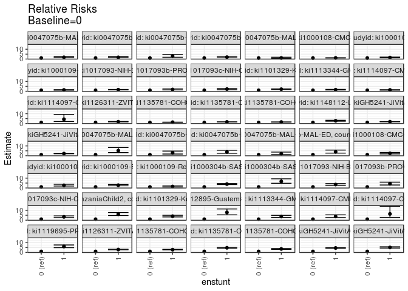

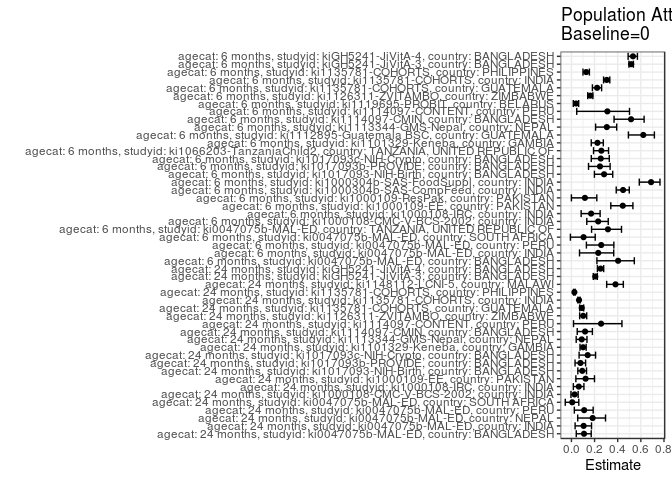

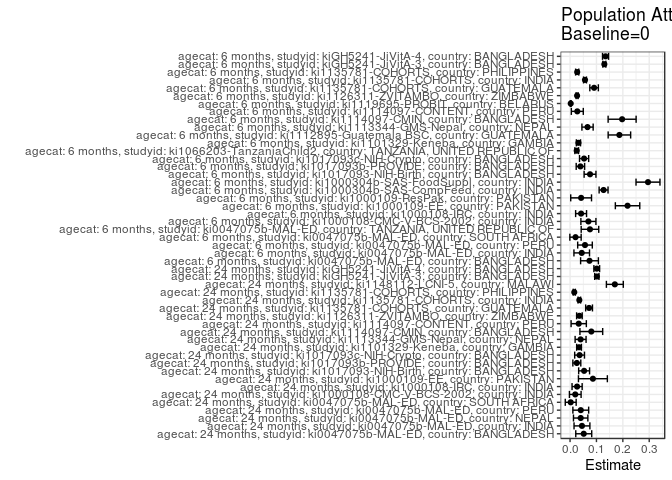

## Results Table

### Parameter: TSM

| agecat | studyid | country | intervention_level | baseline_level | estimate | ci_lower | ci_upper |
| --- | --- | --- | --- | --- | --- | --- | --- |
| 6 months | ki0047075b-MAL-ED | BANGLADESH | 0 | NA | 0.1089109 | 0.0658611 | 0.1519607 |
| 6 months | ki0047075b-MAL-ED | BANGLADESH | 1 | NA | 0.5641026 | 0.4081509 | 0.7200542 |
| 6 months | ki0047075b-MAL-ED | INDIA | 0 | NA | 0.1464646 | 0.0971115 | 0.1958178 |
| 6 months | ki0047075b-MAL-ED | INDIA | 1 | NA | 0.4210526 | 0.2637391 | 0.5783662 |
| 6 months | ki0047075b-MAL-ED | PERU | 0 | NA | 0.1631799 | 0.1162451 | 0.2101148 |
| 6 months | ki0047075b-MAL-ED | PERU | 1 | NA | 0.6176471 | 0.4540001 | 0.7812940 |
| 6 months | ki0047075b-MAL-ED | SOUTH AFRICA | 0 | NA | 0.1762115 | 0.1265503 | 0.2258726 |
| 6 months | ki0047075b-MAL-ED | SOUTH AFRICA | 1 | NA | 0.3703704 | 0.1878617 | 0.5528790 |
| 6 months | ki0047075b-MAL-ED | TANZANIA, UNITED REPUBLIC OF | 0 | NA | 0.1634615 | 0.1131059 | 0.2138172 |
| 6 months | ki0047075b-MAL-ED | TANZANIA, UNITED REPUBLIC OF | 1 | NA | 0.6410256 | 0.4901684 | 0.7918829 |
| 6 months | ki1000108-CMC-V-BCS-2002 | INDIA | 0 | NA | 0.2312925 | 0.1830283 | 0.2795567 |
| 6 months | ki1000108-CMC-V-BCS-2002 | INDIA | 1 | NA | 0.5733333 | 0.4612465 | 0.6854202 |
| 6 months | ki1000108-IRC | INDIA | 0 | NA | 0.2039106 | 0.1621236 | 0.2456977 |
| 6 months | ki1000108-IRC | INDIA | 1 | NA | 0.5510204 | 0.4115823 | 0.6904585 |
| 6 months | ki1000109-EE | PAKISTAN | 0 | NA | 0.2727273 | 0.2122669 | 0.3331876 |
| 6 months | ki1000109-EE | PAKISTAN | 1 | NA | 0.7682927 | 0.7036317 | 0.8329537 |
| 6 months | ki1000109-ResPak | PAKISTAN | 0 | NA | 0.3179191 | 0.2483827 | 0.3874554 |
| 6 months | ki1000109-ResPak | PAKISTAN | 1 | NA | 0.4696970 | 0.3490386 | 0.5903554 |
| 6 months | ki1000304b-SAS-CompFeed | INDIA | 0 | NA | 0.1574074 | 0.1375016 | 0.1773132 |
| 6 months | ki1000304b-SAS-CompFeed | INDIA | 1 | NA | 0.6236264 | 0.5893059 | 0.6579468 |
| 6 months | ki1000304b-SAS-FoodSuppl | INDIA | 0 | NA | 0.1336207 | 0.0897810 | 0.1774604 |
| 6 months | ki1000304b-SAS-FoodSuppl | INDIA | 1 | NA | 0.8918919 | 0.8417992 | 0.9419846 |
| 6 months | ki1017093-NIH-Birth | BANGLADESH | 0 | NA | 0.1924779 | 0.1560988 | 0.2288569 |
| 6 months | ki1017093-NIH-Birth | BANGLADESH | 1 | NA | 0.6705882 | 0.5705788 | 0.7705977 |
| 6 months | ki1017093b-PROVIDE | BANGLADESH | 0 | NA | 0.1197053 | 0.0923792 | 0.1470315 |
| 6 months | ki1017093b-PROVIDE | BANGLADESH | 1 | NA | 0.5081967 | 0.3826358 | 0.6337577 |
| 6 months | ki1017093c-NIH-Crypto | BANGLADESH | 0 | NA | 0.1566069 | 0.1278168 | 0.1853969 |
| 6 months | ki1017093c-NIH-Crypto | BANGLADESH | 1 | NA | 0.5294118 | 0.4324793 | 0.6263442 |
| 6 months | ki1066203-TanzaniaChild2 | TANZANIA, UNITED REPUBLIC OF | 0 | NA | 0.0719577 | 0.0603044 | 0.0836109 |
| 6 months | ki1066203-TanzaniaChild2 | TANZANIA, UNITED REPUBLIC OF | 1 | NA | 0.4388489 | 0.3563316 | 0.5213662 |

[output cut: 68 more lines]

### Parameter: E(Y)

| agecat | studyid | country | intervention_level | baseline_level | estimate | ci_lower | ci_upper |
| --- | --- | --- | --- | --- | --- | --- | --- |
| 6 months | ki0047075b-MAL-ED | BANGLADESH | NA | NA | 0.1825726 | 0.1336978 | 0.2314474 |
| 6 months | ki0047075b-MAL-ED | INDIA | NA | NA | 0.1906780 | 0.1404524 | 0.2409036 |
| 6 months | ki0047075b-MAL-ED | PERU | NA | NA | 0.2197802 | 0.1705687 | 0.2689917 |
| 6 months | ki0047075b-MAL-ED | SOUTH AFRICA | NA | NA | 0.1968504 | 0.1478551 | 0.2458457 |
| 6 months | ki0047075b-MAL-ED | TANZANIA, UNITED REPUBLIC OF | NA | NA | 0.2388664 | 0.1855834 | 0.2921494 |
| 6 months | ki1000108-CMC-V-BCS-2002 | INDIA | NA | NA | 0.3008130 | 0.2539566 | 0.3476694 |
| 6 months | ki1000108-IRC | INDIA | NA | NA | 0.2457002 | 0.2038248 | 0.2875757 |
| 6 months | ki1000109-EE | PAKISTAN | NA | NA | 0.4906166 | 0.4398159 | 0.5414174 |
| 6 months | ki1000109-ResPak | PAKISTAN | NA | NA | 0.3598326 | 0.2988570 | 0.4208083 |
| 6 months | ki1000304b-SAS-CompFeed | INDIA | NA | NA | 0.2844311 | 0.2666491 | 0.3022132 |
| 6 months | ki1000304b-SAS-FoodSuppl | INDIA | NA | NA | 0.4289474 | 0.3791199 | 0.4787748 |
| 6 months | ki1017093-NIH-Birth | BANGLADESH | NA | NA | 0.2681564 | 0.2306532 | 0.3056597 |
| 6 months | ki1017093b-PROVIDE | BANGLADESH | NA | NA | 0.1589404 | 0.1297581 | 0.1881227 |
| 6 months | ki1017093c-NIH-Crypto | BANGLADESH | NA | NA | 0.2097902 | 0.1799252 | 0.2396552 |
| 6 months | ki1066203-TanzaniaChild2 | TANZANIA, UNITED REPUBLIC OF | NA | NA | 0.0970922 | 0.0842059 | 0.1099785 |
| 6 months | ki1101329-Keneba | GAMBIA | NA | NA | 0.1412159 | 0.1262788 | 0.1561530 |
| 6 months | ki1112895-Guatemala BSC | GUATEMALA | NA | NA | 0.3010033 | 0.2489243 | 0.3530824 |
| 6 months | ki1113344-GMS-Nepal | NEPAL | NA | NA | 0.2163121 | 0.1823021 | 0.2503220 |
| 6 months | ki1114097-CMIN | BANGLADESH | NA | NA | 0.3827160 | 0.3214780 | 0.4439541 |
| 6 months | ki1114097-CONTENT | PERU | NA | NA | 0.0883721 | 0.0503437 | 0.1264005 |
| 6 months | ki1119695-PROBIT | BELARUS | NA | NA | 0.0626864 | 0.0488489 | 0.0765238 |
| 6 months | ki1126311-ZVITAMBO | ZIMBABWE | NA | NA | 0.1628792 | 0.1551057 | 0.1706527 |
| 6 months | ki1135781-COHORTS | GUATEMALA | NA | NA | 0.4099896 | 0.3788775 | 0.4411017 |
| 6 months | ki1135781-COHORTS | INDIA | NA | NA | 0.1854227 | 0.1762253 | 0.1946201 |
| 6 months | ki1135781-COHORTS | PHILIPPINES | NA | NA | 0.2112260 | 0.1958496 | 0.2266024 |
| 6 months | kiGH5241-JiVitA-3 | BANGLADESH | NA | NA | 0.2513830 | 0.2432594 | 0.2595066 |
| 6 months | kiGH5241-JiVitA-4 | BANGLADESH | NA | NA | 0.2527427 | 0.2386864 | 0.2667990 |
| 24 months | ki0047075b-MAL-ED | BANGLADESH | NA | NA | 0.4764151 | 0.4090254 | 0.5438047 |
| 24 months | ki0047075b-MAL-ED | INDIA | NA | NA | 0.4273128 | 0.3628178 | 0.4918077 |
| 24 months | ki0047075b-MAL-ED | NEPAL | NA | NA | 0.2192982 | 0.1654718 | 0.2731246 |
| 24 months | ki0047075b-MAL-ED | PERU | NA | NA | 0.3681592 | 0.3013164 | 0.4350020 |
| 24 months | ki0047075b-MAL-ED | SOUTH AFRICA | NA | NA | 0.3529412 | 0.2921001 | 0.4137823 |
| 24 months | ki1000108-CMC-V-BCS-2002 | INDIA | NA | NA | 0.7169811 | 0.6710815 | 0.7628807 |
| 24 months | ki1000108-IRC | INDIA | NA | NA | 0.4205379 | 0.3726382 | 0.4684376 |
| 24 months | ki1000109-EE | PAKISTAN | NA | NA | 0.7065868 | 0.6373214 | 0.7758523 |
| 24 months | ki1017093-NIH-Birth | BANGLADESH | NA | NA | 0.5687646 | 0.5218455 | 0.6156837 |
| 24 months | ki1017093b-PROVIDE | BANGLADESH | NA | NA | 0.3287197 | 0.2903909 | 0.3670485 |
| 24 months | ki1017093c-NIH-Crypto | BANGLADESH | NA | NA | 0.2568093 | 0.2190047 | 0.2946140 |
| 24 months | ki1101329-Keneba | GAMBIA | NA | NA | 0.3368116 | 0.3145020 | 0.3591212 |
| 24 months | ki1113344-GMS-Nepal | NEPAL | NA | NA | 0.4487705 | 0.4045970 | 0.4929440 |
| 24 months | ki1114097-CMIN | BANGLADESH | NA | NA | 0.6818182 | 0.6230135 | 0.7406228 |
| 24 months | ki1114097-CONTENT | PERU | NA | NA | 0.1280488 | 0.0767522 | 0.1793453 |
| 24 months | ki1126311-ZVITAMBO | ZIMBABWE | NA | NA | 0.3469512 | 0.3239068 | 0.3699956 |
| 24 months | ki1135781-COHORTS | GUATEMALA | NA | NA | 0.8112150 | 0.7877559 | 0.8346740 |
| 24 months | ki1135781-COHORTS | INDIA | NA | NA | 0.5351321 | 0.5217497 | 0.5485145 |
| 24 months | ki1135781-COHORTS | PHILIPPINES | NA | NA | 0.6229039 | 0.6036892 | 0.6421186 |
| 24 months | ki1148112-LCNI-5 | MALAWI | NA | NA | 0.4455959 | 0.4050760 | 0.4861157 |
| 24 months | kiGH5241-JiVitA-3 | BANGLADESH | NA | NA | 0.4910797 | 0.4779658 | 0.5041936 |
| 24 months | kiGH5241-JiVitA-4 | BANGLADESH | NA | NA | 0.4008838 | 0.3839145 | 0.4178532 |

### Parameter: RR

| agecat | studyid | country | intervention_level | baseline_level | estimate | ci_lower | ci_upper |
| --- | --- | --- | --- | --- | --- | --- | --- |
| 6 months | ki0047075b-MAL-ED | BANGLADESH | 0 | 0 | 1.000000 | 1.0000000 | 1.000000 |
| 6 months | ki0047075b-MAL-ED | BANGLADESH | 1 | 0 | 5.179487 | 3.1974200 | 8.390229 |
| 6 months | ki0047075b-MAL-ED | INDIA | 0 | 0 | 1.000000 | 1.0000000 | 1.000000 |
| 6 months | ki0047075b-MAL-ED | INDIA | 1 | 0 | 2.874773 | 1.7381963 | 4.754538 |
| 6 months | ki0047075b-MAL-ED | PERU | 0 | 0 | 1.000000 | 1.0000000 | 1.000000 |
| 6 months | ki0047075b-MAL-ED | PERU | 1 | 0 | 3.785068 | 2.5599890 | 5.596406 |
| 6 months | ki0047075b-MAL-ED | SOUTH AFRICA | 0 | 0 | 1.000000 | 1.0000000 | 1.000000 |
| 6 months | ki0047075b-MAL-ED | SOUTH AFRICA | 1 | 0 | 2.101852 | 1.1914205 | 3.707995 |
| 6 months | ki0047075b-MAL-ED | TANZANIA, UNITED REPUBLIC OF | 0 | 0 | 1.000000 | 1.0000000 | 1.000000 |
| 6 months | ki0047075b-MAL-ED | TANZANIA, UNITED REPUBLIC OF | 1 | 0 | 3.921569 | 2.6613346 | 5.778567 |
| 6 months | ki1000108-CMC-V-BCS-2002 | INDIA | 0 | 0 | 1.000000 | 1.0000000 | 1.000000 |
| 6 months | ki1000108-CMC-V-BCS-2002 | INDIA | 1 | 0 | 2.478823 | 1.8623509 | 3.299360 |
| 6 months | ki1000108-IRC | INDIA | 0 | 0 | 1.000000 | 1.0000000 | 1.000000 |
| 6 months | ki1000108-IRC | INDIA | 1 | 0 | 2.702265 | 1.9512389 | 3.742357 |
| 6 months | ki1000109-EE | PAKISTAN | 0 | 0 | 1.000000 | 1.0000000 | 1.000000 |
| 6 months | ki1000109-EE | PAKISTAN | 1 | 0 | 2.817073 | 2.2223658 | 3.570925 |
| 6 months | ki1000109-ResPak | PAKISTAN | 0 | 0 | 1.000000 | 1.0000000 | 1.000000 |
| 6 months | ki1000109-ResPak | PAKISTAN | 1 | 0 | 1.477410 | 1.0543281 | 2.070268 |
| 6 months | ki1000304b-SAS-CompFeed | INDIA | 0 | 0 | 1.000000 | 1.0000000 | 1.000000 |
| 6 months | ki1000304b-SAS-CompFeed | INDIA | 1 | 0 | 3.961862 | 3.4899143 | 4.497631 |
| 6 months | ki1000304b-SAS-FoodSuppl | INDIA | 0 | 0 | 1.000000 | 1.0000000 | 1.000000 |
| 6 months | ki1000304b-SAS-FoodSuppl | INDIA | 1 | 0 | 6.674804 | 4.7849562 | 9.311058 |
| 6 months | ki1017093-NIH-Birth | BANGLADESH | 0 | 0 | 1.000000 | 1.0000000 | 1.000000 |
| 6 months | ki1017093-NIH-Birth | BANGLADESH | 1 | 0 | 3.483976 | 2.7385169 | 4.432358 |
| 6 months | ki1017093b-PROVIDE | BANGLADESH | 0 | 0 | 1.000000 | 1.0000000 | 1.000000 |
| 6 months | ki1017093b-PROVIDE | BANGLADESH | 1 | 0 | 4.245397 | 3.0326883 | 5.943043 |
| 6 months | ki1017093c-NIH-Crypto | BANGLADESH | 0 | 0 | 1.000000 | 1.0000000 | 1.000000 |
| 6 months | ki1017093c-NIH-Crypto | BANGLADESH | 1 | 0 | 3.380515 | 2.6079593 | 4.381924 |
| 6 months | ki1066203-TanzaniaChild2 | TANZANIA, UNITED REPUBLIC OF | 0 | 0 | 1.000000 | 1.0000000 | 1.000000 |
| 6 months | ki1066203-TanzaniaChild2 | TANZANIA, UNITED REPUBLIC OF | 1 | 0 | 6.098709 | 4.7584384 | 7.816483 |

[output cut: 68 more lines]

### Parameter: PAR

| agecat | studyid | country | intervention_level | baseline_level | estimate | ci_lower | ci_upper |
| --- | --- | --- | --- | --- | --- | --- | --- |
| 6 months | ki0047075b-MAL-ED | BANGLADESH | 0 | NA | 0.0736617 | 0.0399679 | 0.1073556 |
| 6 months | ki0047075b-MAL-ED | INDIA | 0 | NA | 0.0442133 | 0.0146961 | 0.0737306 |
| 6 months | ki0047075b-MAL-ED | PERU | 0 | NA | 0.0566003 | 0.0288948 | 0.0843058 |
| 6 months | ki0047075b-MAL-ED | SOUTH AFRICA | 0 | NA | 0.0206389 | -0.0007766 | 0.0420545 |
| 6 months | ki0047075b-MAL-ED | TANZANIA, UNITED REPUBLIC OF | 0 | NA | 0.0754049 | 0.0421764 | 0.1086333 |
| 6 months | ki1000108-CMC-V-BCS-2002 | INDIA | 0 | NA | 0.0695205 | 0.0410071 | 0.0980339 |
| 6 months | ki1000108-IRC | INDIA | 0 | NA | 0.0417896 | 0.0211051 | 0.0624742 |
| 6 months | ki1000109-EE | PAKISTAN | 0 | NA | 0.2178893 | 0.1716324 | 0.2641463 |
| 6 months | ki1000109-ResPak | PAKISTAN | 0 | NA | 0.0419136 | 0.0025019 | 0.0813252 |
| 6 months | ki1000304b-SAS-CompFeed | INDIA | 0 | NA | 0.1270237 | 0.1101277 | 0.1439197 |
| 6 months | ki1000304b-SAS-FoodSuppl | INDIA | 0 | NA | 0.2953267 | 0.2499623 | 0.3406911 |
| 6 months | ki1017093-NIH-Birth | BANGLADESH | 0 | NA | 0.0756785 | 0.0532727 | 0.0980844 |
| 6 months | ki1017093b-PROVIDE | BANGLADESH | 0 | NA | 0.0392351 | 0.0232439 | 0.0552262 |
| 6 months | ki1017093c-NIH-Crypto | BANGLADESH | 0 | NA | 0.0531834 | 0.0358761 | 0.0704906 |
| 6 months | ki1066203-TanzaniaChild2 | TANZANIA, UNITED REPUBLIC OF | 0 | NA | 0.0251345 | 0.0181442 | 0.0321248 |
| 6 months | ki1101329-Keneba | GAMBIA | 0 | NA | 0.0318079 | 0.0239010 | 0.0397147 |
| 6 months | ki1112895-Guatemala BSC | GUATEMALA | 0 | NA | 0.1869683 | 0.1443605 | 0.2295760 |
| 6 months | ki1113344-GMS-Nepal | NEPAL | 0 | NA | 0.0662063 | 0.0449066 | 0.0875061 |
| 6 months | ki1114097-CMIN | BANGLADESH | 0 | NA | 0.1972856 | 0.1442454 | 0.2503257 |
| 6 months | ki1114097-CONTENT | PERU | 0 | NA | 0.0274584 | 0.0048058 | 0.0501110 |
| 6 months | ki1119695-PROBIT | BELARUS | 0 | NA | 0.0024893 | 0.0012051 | 0.0037736 |
| 6 months | ki1126311-ZVITAMBO | ZIMBABWE | 0 | NA | 0.0266380 | 0.0228802 | 0.0303959 |
| 6 months | ki1135781-COHORTS | GUATEMALA | 0 | NA | 0.0910774 | 0.0748877 | 0.1072670 |
| 6 months | ki1135781-COHORTS | INDIA | 0 | NA | 0.0566198 | 0.0511258 | 0.0621138 |
| 6 months | ki1135781-COHORTS | PHILIPPINES | 0 | NA | 0.0270567 | 0.0210361 | 0.0330773 |
| 6 months | kiGH5241-JiVitA-3 | BANGLADESH | 0 | NA | 0.1299172 | 0.1242189 | 0.1356155 |
| 6 months | kiGH5241-JiVitA-4 | BANGLADESH | 0 | NA | 0.1344693 | 0.1230267 | 0.1459120 |
| 24 months | ki0047075b-MAL-ED | BANGLADESH | 0 | NA | 0.0518341 | 0.0216109 | 0.0820572 |
| 24 months | ki0047075b-MAL-ED | INDIA | 0 | NA | 0.0451138 | 0.0150714 | 0.0751562 |
| 24 months | ki0047075b-MAL-ED | NEPAL | 0 | NA | 0.0401938 | 0.0129281 | 0.0674595 |
| 24 months | ki0047075b-MAL-ED | PERU | 0 | NA | 0.0405730 | 0.0106796 | 0.0704664 |
| 24 months | ki0047075b-MAL-ED | SOUTH AFRICA | 0 | NA | 0.0024739 | -0.0181585 | 0.0231063 |
| 24 months | ki1000108-CMC-V-BCS-2002 | INDIA | 0 | NA | 0.0197022 | -0.0024163 | 0.0418207 |
| 24 months | ki1000108-IRC | INDIA | 0 | NA | 0.0266831 | 0.0075301 | 0.0458362 |
| 24 months | ki1000109-EE | PAKISTAN | 0 | NA | 0.0865868 | 0.0318282 | 0.1413455 |
| 24 months | ki1017093-NIH-Birth | BANGLADESH | 0 | NA | 0.0532716 | 0.0326077 | 0.0739355 |
| 24 months | ki1017093b-PROVIDE | BANGLADESH | 0 | NA | 0.0256309 | 0.0106070 | 0.0406548 |
| 24 months | ki1017093c-NIH-Crypto | BANGLADESH | 0 | NA | 0.0360886 | 0.0175345 | 0.0546427 |
| 24 months | ki1101329-Keneba | GAMBIA | 0 | NA | 0.0340356 | 0.0250479 | 0.0430233 |
| 24 months | ki1113344-GMS-Nepal | NEPAL | 0 | NA | 0.0399035 | 0.0191703 | 0.0606367 |
| 24 months | ki1114097-CMIN | BANGLADESH | 0 | NA | 0.0805110 | 0.0373888 | 0.1236332 |
| 24 months | ki1114097-CONTENT | PERU | 0 | NA | 0.0328107 | 0.0039066 | 0.0617148 |
| 24 months | ki1126311-ZVITAMBO | ZIMBABWE | 0 | NA | 0.0354292 | 0.0248452 | 0.0460132 |
| 24 months | ki1135781-COHORTS | GUATEMALA | 0 | NA | 0.0720258 | 0.0591228 | 0.0849288 |
| 24 months | ki1135781-COHORTS | INDIA | 0 | NA | 0.0351321 | 0.0302661 | 0.0399981 |
| 24 months | ki1135781-COHORTS | PHILIPPINES | 0 | NA | 0.0159775 | 0.0119597 | 0.0199952 |
| 24 months | ki1148112-LCNI-5 | MALAWI | 0 | NA | 0.1697338 | 0.1377091 | 0.2017584 |
| 24 months | kiGH5241-JiVitA-3 | BANGLADESH | 0 | NA | 0.1014802 | 0.0934046 | 0.1095559 |
| 24 months | kiGH5241-JiVitA-4 | BANGLADESH | 0 | NA | 0.1011194 | 0.0902982 | 0.1119407 |

### Parameter: PAF

| agecat | studyid | country | intervention_level | baseline_level | estimate | ci_lower | ci_upper |
| --- | --- | --- | --- | --- | --- | --- | --- |
| 6 months | ki0047075b-MAL-ED | BANGLADESH | 0 | NA | 0.4034653 | 0.2203556 | 0.5435693 |
| 6 months | ki0047075b-MAL-ED | INDIA | 0 | NA | 0.2318743 | 0.0699722 | 0.3655920 |
| 6 months | ki0047075b-MAL-ED | PERU | 0 | NA | 0.2575314 | 0.1294746 | 0.3667506 |
| 6 months | ki0047075b-MAL-ED | SOUTH AFRICA | 0 | NA | 0.1048458 | -0.0088343 | 0.2057159 |
| 6 months | ki0047075b-MAL-ED | TANZANIA, UNITED REPUBLIC OF | 0 | NA | 0.3156780 | 0.1742730 | 0.4328675 |
| 6 months | ki1000108-CMC-V-BCS-2002 | INDIA | 0 | NA | 0.2311087 | 0.1328758 | 0.3182131 |
| 6 months | ki1000108-IRC | INDIA | 0 | NA | 0.1700838 | 0.0840488 | 0.2480375 |
| 6 months | ki1000109-EE | PAKISTAN | 0 | NA | 0.4441133 | 0.3404247 | 0.5315015 |
| 6 months | ki1000109-ResPak | PAKISTAN | 0 | NA | 0.1164807 | -0.0001117 | 0.2194808 |
| 6 months | ki1000304b-SAS-CompFeed | INDIA | 0 | NA | 0.4465887 | 0.3872813 | 0.5001555 |
| 6 months | ki1000304b-SAS-FoodSuppl | INDIA | 0 | NA | 0.6884916 | 0.5865198 | 0.7653153 |
| 6 months | ki1017093-NIH-Birth | BANGLADESH | 0 | NA | 0.2822179 | 0.1986919 | 0.3570374 |
| 6 months | ki1017093b-PROVIDE | BANGLADESH | 0 | NA | 0.2468539 | 0.1478435 | 0.3343605 |
| 6 months | ki1017093c-NIH-Crypto | BANGLADESH | 0 | NA | 0.2535073 | 0.1717449 | 0.3271985 |
| 6 months | ki1066203-TanzaniaChild2 | TANZANIA, UNITED REPUBLIC OF | 0 | NA | 0.2588725 | 0.1912212 | 0.3208651 |
| 6 months | ki1101329-Keneba | GAMBIA | 0 | NA | 0.2252428 | 0.1713755 | 0.2756082 |
| 6 months | ki1112895-Guatemala BSC | GUATEMALA | 0 | NA | 0.6211501 | 0.4925719 | 0.7171476 |
| 6 months | ki1113344-GMS-Nepal | NEPAL | 0 | NA | 0.3060687 | 0.2089183 | 0.3912884 |
| 6 months | ki1114097-CMIN | BANGLADESH | 0 | NA | 0.5154881 | 0.3684446 | 0.6282959 |
| 6 months | ki1114097-CONTENT | PERU | 0 | NA | 0.3107133 | 0.0459028 | 0.5020255 |
| 6 months | ki1119695-PROBIT | BELARUS | 0 | NA | 0.0397111 | 0.0162372 | 0.0626249 |
| 6 months | ki1126311-ZVITAMBO | ZIMBABWE | 0 | NA | 0.1635448 | 0.1410853 | 0.1854169 |
| 6 months | ki1135781-COHORTS | GUATEMALA | 0 | NA | 0.2221455 | 0.1813324 | 0.2609240 |
| 6 months | ki1135781-COHORTS | INDIA | 0 | NA | 0.3053554 | 0.2779773 | 0.3316953 |
| 6 months | ki1135781-COHORTS | PHILIPPINES | 0 | NA | 0.1280937 | 0.0999714 | 0.1553373 |
| 6 months | kiGH5241-JiVitA-3 | BANGLADESH | 0 | NA | 0.5168099 | 0.4971087 | 0.5357393 |
| 6 months | kiGH5241-JiVitA-4 | BANGLADESH | 0 | NA | 0.5320404 | 0.4900866 | 0.5705424 |
| 24 months | ki0047075b-MAL-ED | BANGLADESH | 0 | NA | 0.1088003 | 0.0418131 | 0.1711044 |
| 24 months | ki0047075b-MAL-ED | INDIA | 0 | NA | 0.1055756 | 0.0317818 | 0.1737452 |
| 24 months | ki0047075b-MAL-ED | NEPAL | 0 | NA | 0.1832836 | 0.0541977 | 0.2947515 |
| 24 months | ki0047075b-MAL-ED | PERU | 0 | NA | 0.1102050 | 0.0250883 | 0.1878905 |
| 24 months | ki0047075b-MAL-ED | SOUTH AFRICA | 0 | NA | 0.0070093 | -0.0532053 | 0.0637813 |
| 24 months | ki1000108-CMC-V-BCS-2002 | INDIA | 0 | NA | 0.0274794 | -0.0040673 | 0.0580350 |
| 24 months | ki1000108-IRC | INDIA | 0 | NA | 0.0634500 | 0.0165643 | 0.1081005 |
| 24 months | ki1000109-EE | PAKISTAN | 0 | NA | 0.1225424 | 0.0382945 | 0.1994099 |
| 24 months | ki1017093-NIH-Birth | BANGLADESH | 0 | NA | 0.0936620 | 0.0554209 | 0.1303549 |
| 24 months | ki1017093b-PROVIDE | BANGLADESH | 0 | NA | 0.0779720 | 0.0312083 | 0.1224783 |
| 24 months | ki1017093c-NIH-Crypto | BANGLADESH | 0 | NA | 0.1405269 | 0.0664728 | 0.2087065 |
| 24 months | ki1101329-Keneba | GAMBIA | 0 | NA | 0.1010524 | 0.0740429 | 0.1272740 |
| 24 months | ki1113344-GMS-Nepal | NEPAL | 0 | NA | 0.0889174 | 0.0411061 | 0.1343448 |
| 24 months | ki1114097-CMIN | BANGLADESH | 0 | NA | 0.1180828 | 0.0501048 | 0.1811960 |
| 24 months | ki1114097-CONTENT | PERU | 0 | NA | 0.2562358 | 0.0179802 | 0.4366864 |
| 24 months | ki1126311-ZVITAMBO | ZIMBABWE | 0 | NA | 0.1021157 | 0.0711216 | 0.1320756 |
| 24 months | ki1135781-COHORTS | GUATEMALA | 0 | NA | 0.0887875 | 0.0713595 | 0.1058885 |
| 24 months | ki1135781-COHORTS | INDIA | 0 | NA | 0.0656513 | 0.0563430 | 0.0748677 |
| 24 months | ki1135781-COHORTS | PHILIPPINES | 0 | NA | 0.0256500 | 0.0190710 | 0.0321848 |
| 24 months | ki1148112-LCNI-5 | MALAWI | 0 | NA | 0.3809142 | 0.3047524 | 0.4487328 |
| 24 months | kiGH5241-JiVitA-3 | BANGLADESH | 0 | NA | 0.2066472 | 0.1891219 | 0.2237937 |
| 24 months | kiGH5241-JiVitA-4 | BANGLADESH | 0 | NA | 0.2522412 | 0.2245605 | 0.2789337 |